# Challenge Problems

Cameron Malloy

Spring 2019

## Control and While Loops

### Problems

#### Problem 1: right_triangle

The function `right_triangle` checks to see if three sides, `a`, `b`, or `c` can be possible sides of a right triangle, not necessarily in numerical order (i.e. `a` can be 4, `b` can be 5, and `c` can be 3.. It returns True if they are sides of a triangle, False otherwise. If you’re unfamiliar, the Pythagorean Theorem is useful here:
$$x^2 + y^2 = z^2 \text{ if } x, y, \text{ and } z \text{ are sides of a triangle, and } z \text{ is the hypotenuse.}$$
This draws inspiration to the first exam I took (Fall 2017 MT1).
This tests material from HW1 and the second discussion

```python
def right_triangle(a, b, c):
    '''
    >>> right_triangle(1, 1, 1)
    False
    >>> right_triangle(3, 4, 5)
    True
    '''
    one_side = _______________________________________
    hypotenuse = _____________________________________
    other_side = _____________________________________
    return ___________________________________________
```

#### Problem 2: is_hypotenuse

The function `is_hypotenuse` checks to see if an integer, `h` can be a hypotenuse for some right triangle with sides `i` and `j`. You may use the function right_triangle above as if it’s correct. If `h` is a hypotenuse, then print out the sides in increasing order and return True. If `h` is not a hypotenuse, then return False. You are **not** allowed to use the built-in **`min`** or **`max`** functions.  
I think this is an interesting case of using a double while loop, and it’s good to wrap your head around one. There’s also some insane numbers that happen to be hypotenuses! After solving, I encourage you to try out some random numbers you think can’t be a hypotenuse.

```python
def is_hypotenuse(h):
    '''
    >>> is_hypotenuse(1)
    False
    >>> is_hypotenuse(5)
    3 4 5
    True
    '''
    i, j = _____________, _____________
    while _____________________________:
        while _________________________:
            if ________________________:
                print(____, ____, ____)
                _______________________
            ___________________________
        _______________________________
        _______________________________
    return False
```

### Solutions

#### Problem 1: right_triangle

We’re given three sides, but we don’t know which one is the hypotenuse. It’s necessary to know the hypotenuse to apply the Pythagorean Theorem. However, we can use `min` and `max` to find the biggest and smallest side. The biggest one is the hypotenuse by definition and the smallest one is just a side. This leaves us with the task of finding the remaining side, since min and max doesn’t associate the mininum and maximum values with the variables.  
We can notice that the sum of all three sides minus two of the sides will give the remaining side. Putting this all together produces the first three variables. Then we apply the Pythagorean Theorem to check if the sides are valid.

```python
def right_triangle(a, b, c):
    '''
    >>> right_triangle(1, 1, 1)
    False
    >>> right_triangle(3, 4, 5)
    True
    '''
    one_side = min(a, b, c)
    hypotenuse = max(a, b, c)
    other_side = a + b + c - one_side - hypotenuse
    return one_side ** 2 + other_side ** 2 == hypotenuse ** 2
```

#### Problem 2: is_hypotenuse

The trick to this problem is to check all possible combinations of sides and see if they form a triangle. Since we’re given the hypotenuse, we just have to check all combinations of `i`, `j`, `h` where `i` and `j` are less than h. But then we have to print out the values in increasing order, and since we can’t use `min` or `max`, we can ensure that `j` is always less than or equal to `i` so when we print out the values, we know that `j` $\leq$ `i` $<$ `h`.  
This leads us to the idea where we loop through every possible value of `i`, starting at $0$ (could also be another number, but $0$ works fine). Then for each `i`, we can loop through each possible value of `j` starting at $0$ up to and including the value of `i`. Each time, we’ll check if this combination of `i`, `j`, `h` happen to be a right triangle.

```python
def is_hypotenuse(h):
    '''
    >>> is_hypotenuse(1)
    False
    >>> is_hypotenuse(5)
    3 4 5
    True
    '''
    i, j = 0, 0
    while i < h:
        while j <= i:
            if right_triangle(i, j, h):
                print(j, i, h)
                return True
            j += 1
        i += 1
        j = 0
    return False
```

## Higher Order Functions

### Problems

#### Problem 1: create_account

This is a higher order function problem that’s super similar to a Homework 5 problem, `make_withdraw`. It’s just to get people familiar with higher order functions.  
`create_account` will create an account with a `username`, `password`, and the maximum number of consecutive incorrect login attempts, `n`, until the account is suspended. You can call the account on a password attempt. If it’s wrong, then it will display

`Incorrect Password <attempts_left> attempt(s) remaining`

If the password is correct, it will call the `account` function which will `print` the `username`.

```python
def create_account(username, password, n):
    '''
    >>> cameron = create_account('cmalloy', 'pumpernickel', 2)
    >>> cameron = cameron('pump')
    Incorrect Password 1 attempt(s) remaining
    >>> cameron = cameron('pumps')
    Account Suspended
    >>> cameron = create_account('cmalloy', 'pumpernickel', 2)
    >>> cameron = cameron('pumpernickel')
    You username is cmalloy
    >>> cameron = cameron('pumps')
    Incorrect Password 1 attempt(s) remaining
    >>> cameron = cameron('pumpernickel')
    Your username is cmalloy
    '''
    def login(password_attempt):

        def attempts():
            attempts_left = _____________________
            if attempts_left <= ___:
                print('Account Suspended')
            else:
                print('Incorrect Password', attempts_left, 'attempt(s) remaining')
                return ___________________________________________________________

        if password == password_attempt:
            return account(username)
        else:
            return attempts()

    def account(username):
        print('Your username is', username)
        return ___________________________________________________________

    return __________
```

### Solutions

We know that `create_account` returns a function. We have $2$ choices, `login` and `account`. We notice that in the doctests, takes in a password and does some stuff, and that some stuff matches the `login` function. So, we’ll return the `login` function.  
When we look at the `login` function, we see that the function `attempts` is only called when we get the password wrong. That means we have used $1$ of our attempts. So, we’ll set `attempts_left` to be $n - 1$. Then we check if there are still more attempts left.  
The trickiest part of the problem is figuring out what to return from `login` and `account`. In both instances, we want to get back to the $login$ function. If we get a password wrong, then we need to update the `n` variable, so we can create a new account with the same username and password, but with an updated `n`. In the case of `account`, we can do the same exact thing, or we can just return the login function directly.

```python
def create_account(username, password, n):
    '''
    >>> cameron = create_account('cmalloy', 'pumpernickel', 2)
    >>> cameron = cameron('pump')
    Incorrect Password 1 attempt(s) remaining
    >>> cameron = cameron('pumps')
    Account Suspended
    >>> cameron = create_account('cmalloy', 'pumpernickel', 2)
    >>> cameron = cameron('pumpernickel')
    You username is cmalloy
    >>> cameron = cameron('pumps')
    Incorrect Password 1 attempt(s) remaining
    >>> cameron = cameron('pumpernickel')
    Your username is cmalloy
    '''
    def login(password_attempt):

        def attempts():
            attempts_left = n - 1
            if attempts_left <= 0:
                print('Account Suspended')
            else:
                print('Incorrect Password', attempts_left, 'attempt(s) remaining')
                return create_account(username, password, attempts_left)

        if password == password_attempt:
            return account(username)
        else:
            return attempts()

    def account(username):
        print('Your username is', username)
        return login    # or you can return this: create_account(username, password, n)

    return login
```

## Tree Recursion

### Problems

#### Problem 1: sum_q

The function `$sum_q$` takes in 3 values, `a`, `b`, and `c`. It returns True if there exists a sum of elements of this form:
$$(a + nb) + (b + ma) = c \text{ where } n, m \text{ are integers, not necessarily equivalent and can be 0}$$

```python
def sum_q(a, b, c):
    '''
    >>> sum_q(3, 2, 11)
    True
    >>> sum_q(3, 7, 65)
    True
    >>> sum_q(23, 6, 401)
    True
    >>> sum_q(7, 4, 9)
    False
    >>> sum_q(5, 3, 4)
    False
    >>> sum_q(13, 13, 2309)
    False
    '''
    if __________________________________________:
        return __________________________________
    elif ________________________________________:
        return __________________________________
    else:
        return ____________________________________________________
```

#### Problem 2.1 String Play

Write a function `denominaton_as_int` which takes a string, `denomination` of the form `"$####"` and returns just the `####`. The string `denomination` always has the form `"$####"` where the first element is always a `$` and the rest of the string is numbers. To reiterate, you are to return the numbers, as an integer.  
Hint 1: The built-in function `int` turns a string of numbers into an int (i.e. `int('123')` will return `123`)  
Hint 2: Strings can be indexed just like lists (where each character of a string is it’s own element). List slices also work!

```python
def denomination_as_int(denomination):
    '''
    >>> integer = denomination_as_int('$123')
    >>> integer
    123
    >>> type(integer) == int
    True
    '''
    return __________________________________
```

#### Problem 2.2: exact_change

You’re at your local grocery store and when you get to the register the cashier says to you “Sorry, but our credit card machine is down and all the machines are out of cash, and we don’t take venmo. So we can only except money greater than or equal to the price of what you’re buying”. You, being a college student, don’t want to waste any money, so you are determined to only pay with the exact change (assume your total is always a whole number for simplicity).

Write a function `exact_change` which takes in a dictionary, `wallet` and a number, `amount` and returns whether your wallet contains exactly amount. Wallets are dictionaries where the keys are US denominations represented as strings and the values are numbers representing how many of those denominations you have. Here is an example of a wallet:

```python
wallet = {
        '$1': 2,
        '$5': 4,
        '$10': 1,
        '$20': 0
}
```

This means the total amount of money in the wallet is $\$32$. There are $2$ $\$1$ bills, $4$ $\$5$ bills, $1$ $\$10$ bills, and no $\$20$ bills. Remember the built-in dictionary methods: `<dict>.keys()` returns a list of the keys of the dictionary, `dict.values()` returns a list of the values of the dictionary, and `dict(<existing dictionary>)` which takes in an optional argument and will return a new dictionary, either a copy if the optional argument is given or a new empty dictionary. You may use `denomination_as_int` as if it were correct in problem 2.1.  
Recall that `any(<list>)` will return `True` if **any** the elements are Truth-y and `False` all the elements are False-y

```python
def exact_change(wallet, amount):
    '''
    >>> exact_change(wallet, 2) # Using wallet from above
    True
    >>> exact_change(wallet, 7) # Use 2 $1 bills and 1 $5 bill
    True
    >>> exact_change(18)
    False
    '''
    if __________________________:
        return __________________
    elif ________________________:
        return __________________
    else:
        results = []
        for ___________________________________________:
            updated_wallet = __________________________
            if ________________________________________:
                _______________________________________
                # the following 2 lines is just 1 line split into 2
                results.___________(____________________________
                        ________________________________________)
        return any(____________________________________)
```

### Solutions

#### Problem 1: sum_q

The way I approach tree problems is to draw the tree diagram! I normally take a simple case from the doctest and try this out. It helps figure out the base cases and recursive calls. Remember that the values within the nodes are the inputs to the call to the function / rerursive call and connections between nodes are recursive calls themselves. This is the final version of the tree diagram for the first doctest:

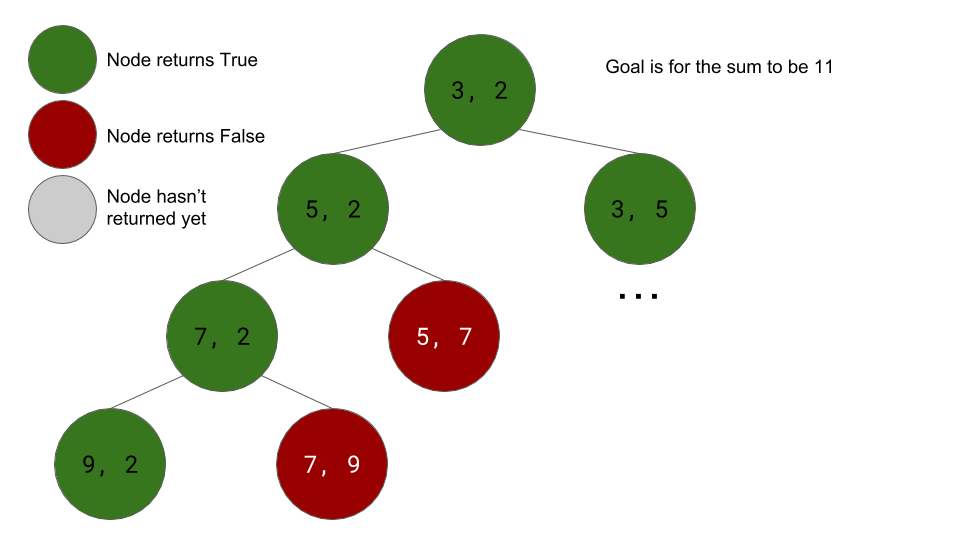

Here’s the link to a step-by-step construction of the tree diagram: [sum_q diagram slides](https://docs.google.com/presentation/d/1vcQnESjSdvS9NgMlkfPyCZEcFVeZjhax6dyJJxbkYBc/edit?usp=sharing)

The tree diagram shows us our base cases and recursive calls. The base cases are when the tree leaves return something. So, the node $9$, $2$ returned True because the $9 + 2 = 11$. However, $5 + 7 = 12 > 11$, so all nodes that originate from that node will be greater than $12$, so those sums won’t ever be $11$.  
To figure out our recursive calls, we go up to the very first node and look at the connections originating from that root node. So the root node is $3$ and $2$. The first connection to the left added changed the first input `a` to `a + b` and the second connection turned the input `b` to `b + a`.  
Then we can use the leap of faith and ask ourselves, what does `sum_q(5, 2)` return? And by the tree diagram it returns True. We can say the same for `sum_q(3, 5)`. Then we return True if at least one of them is True, so that leads to the idea of using the or operator.  
Now that we understand the base cases and recursive calls, we can go onto the solution.

```python
def sum_q(a, b, c):
    '''
    >>> sum_q(3, 2, 11)
    True
    >>> sum_q(3, 7, 65)
    True
    >>> sum_q(23, 6, 401)
    True
    >>> sum_q(7, 4, 9)
    False
    >>> sum_q(5, 3, 4)
    False
    >>> sum_q(13, 13, 2309)
    False
    '''
    if a + b == c:
        return True
    elif a + b > c:
        return False
    else:
        return sum_q(a + b, b, c) or sum_q(a, b + a, c)
```

#### Problem 2.1: String Play

Since strings can be sliced, we take everything but the first element usint this method: `<string>[1:]`. Then we put that into the `int` function.

```python
def denomination_as_int(denomination):
    '''
    >>> integer = denomination_as_int('$123')
    >>> integer
    123
    >>> type(integer) == int
    True
    '''
    return int(denomination[1:])
```

#### Problem 2.2: exact_change

Here’s the final tree diagram:

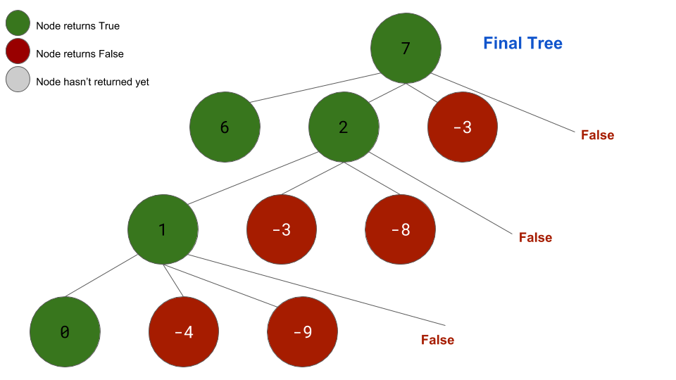

Here’s the link to a step-by-step construction of the tree diagram: [exact_change diagram slides](https://docs.google.com/presentation/d/1wXgaOPQQTpul6FEPP4jSc02AuWsfc8SG9c19SiOhd88/edit?usp=sharing)

Take a look at the slides to get a grasp for the tree diagram, because I’ll be using that in this explanation. From the tree diagram, we can find the base cases, here they are: 1. `amount` equals $0$, return True 2. `amount` falls below $0$, return False 3. There are no more of those denominations, return False

We’re only given $2$ if statements to code for explicit base cases, which means one of them will be fulfilled by the else statement. We also know that we need to make a recursive call on every type of denomination which has a positive number of bills in the wallet. So to make a recursive call over all the denominations, we use a for loop. For each denomination, we have to check whether it has any bills in it, and if it doesn’t then we should just skip it (this would cover the 3rd base case, can you see why?). So, if there are bills in the wallet of that denomination, we have to create a updated wallet that takes that bill away. The last thing we have to do is keep track of all these recursive calls. They give us a results list, so we should add our results from the recursive calls to that list. If any of those results are True, then we return `True`, or else we’ll return `False`, which is exactly what `any` does.

```python
def exact_change(wallet, amount):
    '''
    >>> exact_change(wallet, 2) # Using wallet from above
    True
    >>> exact_change(wallet, 7) # Use 2 $1 bills and 1 $5 bill
    True
    >>> exact_change(18)
    False
    '''
    if amount = 0:
        return True
    elif amount < 0:
        return False
    else:
        results = []
        for denomination in wallet.keys():
            updated_wallet = dict(wallet)
            if updated_wallet[denomination]:
                updated_wallet[denomination] -= 1
                # the following 2 lines is just 1 line split into 2
                results.append(exact_change(updated_wallet,
                        amount - denomination_as_int(denomination)))
        return any(results)
```

## OOP

### Problems

#### Problem 1: The Round Table

King Arthur was a famous king with a famous Round Table! You might’ve heard of him. It was large so all of his knights could sit and discuss matters of the kingdom or battles and other medieval what-nots. What some people don’t know is that when King Arthur had meetings, knights could come and go as they want. Everyone would talk on a first come first serve basis. Historians want to be able to simulate this amazing event in history. Here are the ruels of King Arthur’s Round Table’s discussion:

1. Discussions can only start when King Arthur is at the table (because he must be present at the start)
2. The first person to speak is King Arthur
3. When a knight joins the Round Table, they will be the next person to speak after the previous knight that joined the Round Table (note that King Arthur is also a knight)
4. Any knight can leave the Round Table, so if they leave, the knight behind them will take their place when it’s their turn to speak
5. After all knights at the Round Table has spoken, the order will repeat, starting again with King Arthur
6. The next to speak can not leave the table.

Also, implement the method speak which has the next knight speak his/her mind!

You must store the knights in a linked list.

See an example below this code. You may not need all lines. For simplicity, knights are just strings of their names, you can assume they’re all unique.

```python
class RoundTable():
    def __init__(self):
        self.table = Link('King Arthur') # Step 1
        ________________________________
        self.speaker = _________________
        self.end = ________________

    def add_knight(self, knight):
        ________________________________
        ________________________________
        ________________________________
        ________________________________
        ________________________________
        ________________________________
        print('{} has been JOINED to the Round Table!'.format(knight))

    def remove_knight(self, knight):
        current = ______________________
        ________________________________
        ________________________________:
            ____________________________:
                ________________________
                if current is self.end:
                    ________________________
                print('{} has LEFT the Round Table!'.format(knight))
                return
            ____________________________:
                ________________________
                ________________________

    def speak(self):
        knight_to_speak = ______________
        print('{} HAS SPOKEN!'.format(knight_to_speak))
        ________________________________
        ________________________________
        ________________________________
        ________________________________

    def __repr__(self):
        current = self.speaker.rest
        string = '|{}|'.format(self.speaker.first)
        while current is not self.speaker:
            string += '|{}|'.format(current.first)
            current = current.rest
        return string
```

```python
'''
>>> rt = RoundTable()
>>> rt.speak() # all alone :'(
King Arthur HAS SPOKEN!
>>> rt.add_knight('Lancelot')
Lancelot has JOINED the Round Table!
>>> rt.add_knight('Percival')
Percival has JOINED the Round Table!
>>> rt
|King Arthur||Lancelot||Percival|
>>> rt.speak()
King Arthur HAS SPOKEN!
>>> rt.speak()
Lancelot HAS SPOKEN!
>>> rt.remove_knight('Lancelot') # He needs to eat lunch
Lancelot has LEFT the Round Table!
>>> rt.remove_knight('Percival')
Knight not found or next to speak
>>> rt.speak()
Percival HAS SPOKEN!
>>> rt.remove_knight('Percival')
Percival has LEFT the Round Table!
>>> rt.remove_knight('King Arthur')
Knight not found or next to speak
>>> rt.add_knight('Lancelot') # He's back from lunch!
Lancelot has JOINED the Round Table!
>>> rt.speak()
King Arthur HAS SPOKEN!
>>> rt.remove_knight('King Arthur')
King Arthur has LEFT the Round Table!
'''
```

### Solutions

#### Problem 1: The Round Table

**init**  
Se need this to be a cyclic linked list, because if we go through the whole table, we have to go back to the beginning. We also initialize a speaker and an end to keep track of who’s speaking, and who’s the last person to speak in the order. These two attributes help add and take away knights.

**add_knight**  
Since we’re dealing with linked lists, we have to create a link for the knight itself. Since this knight is the last person to speak in the order, the person to speak after him/her should be the current speaker now. Next, we actually need to have the act of adding the knight to the table, so we set the rest of end to that knight. So now we have a full circle of linked lists with the new addition. Lastly, we have to update the end because we added a new knight.

**remove_knight**  
We can’t remove the speaker, so what we’ll do is start with the knight after the speaker. Then we’ll go through everyone at the table and see if the knight is there. If he/she is, then we’ll remove her. The way we remove a knight is by setting the knight `rest` of the knight in front (in terms of speaking) of it to the knight after it. For instance, if the order is `King Arthur -> Lancelot -> Percival` and the speaker is Percival and we want to remove Lancelot, then we’ll set the `rest` of `King Arthur` to `Percival`. Since we need to keep track of the one in front, I create something called a lag term. It seems counter-intuitive because lag means behind, but it’s actually representing the knight that will speak before the knight we want to remove. If we remove a knight, we have to update the end as well.

```python
class RoundTable():
    def __init__(self):
        self.table = Link('King Arthur') # Step 1
        self.table.rest = self.table
        self.speaker = self.table
        self.end = self.table

    def add_knight(self, knight):
        knight_lnk = Link(knight, self.speaker)
        self.end.rest = knight_lnk
        self.end = knight_lnk
        print('{} has been JOINED to the Round Table!'.format(knight))

    def remove_knight(self, knight):
        current = self.speaker.rest
        lag = self.speaker
        while current is not self.speaker:
            if current.first == knight:
                lag.rest = lag.rest.rest
                if current is self.end:
                    self.end = lag.rest
                print('{} has LEFT the Round Table!'.format(knight))
                return
            else:
                current = current.rest
                lag = lag.rest

    def speak(self):
        knight_to_speak = self.speaker.first
        print('{} HAS SPOKEN!'.format(knight_to_speak))
        self.end = self.speaker
        self.speaker = self.speaker.rest

    def __repr__(self):
        current = self.speaker.rest
        string = '|{}|'.format(self.speaker.first)
        while current is not self.speaker:
            string += '|{}|'.format(current.first)
            current = current.rest
        return string
```

## Trees

### Problems

#### Problem 1: tree_shuffle

For this question, you will be using class-based trees, i.e. the selectors are methods not functions.  
In computer science, trees with very large heights can have a problem (in terms of Order of Growth). Some algorithms rely on trees having the smallest height possible. The function `tree_shuffle` is meant to help with this problem. It takes in a tree, `t`, and value, `val`, and returns a new tree where the root label is the node with `val` as it’s label. Along with making it the new root label, it also turns it’s parent into a branch. This is more helpful visually looking at it:

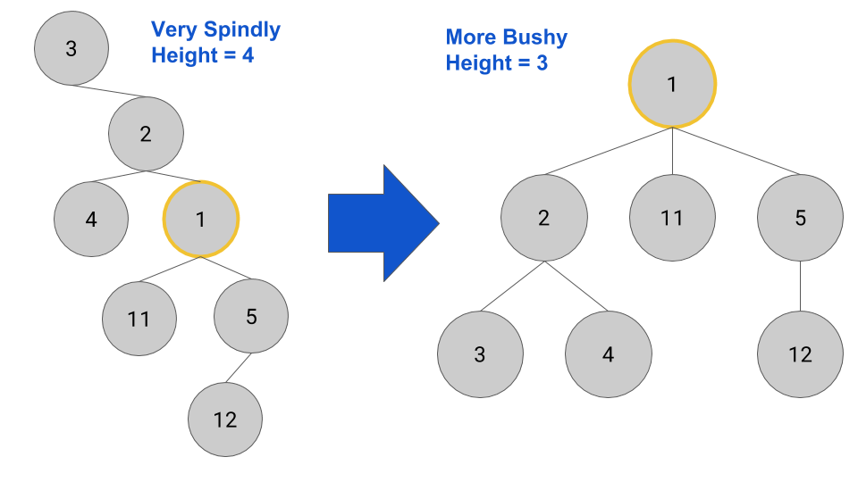

It starts with the tree on the left as `t` and $1$ as it’s `val`. The returned tree is to the right, where $1$ is the root label, it’s parent, $2$, is it’s new branch. Also note that $2$’s parent, $3$ is also $2$’s branch. It’s like you picked up the node $1$ (from the left) and let all the other nodes fall to the bottom (to get the tree on the right).

Python has the ability to return multiple things at once, and you can access all three of those things using the following syntax:

```python
>>> def return123():
...     return 1, 2, 3
...
>>> x, y, z = return123()
>>> x
1
>>> y
2
>>> z
3
```

Here’s another example before you get started:

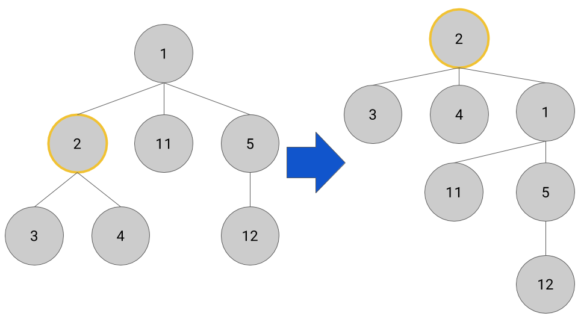

You don’t have to use `copy_tree`, but for your reference:

```python
def copy_tree(t):
    return Tree(t.label, [copy_tree(b) for b in branches.t])
```

`copy_tree` returns a copy of the tree passed in. Editing copied trees doesn’t affect the original tree. **You may also assume all the values in the tree are unique.**

```python
def tree_shuffle(t, val):
    def helper(t, val):
        t = copy_tree(t)
        if label.t == val:
            return _______, _______, ______
        else:
            new_parent = None
            return_tree = None
            new_branches = ____________________________
            ___________________________________________:
                main_tree, child_branch, is_new_parent = _____________________________
                _______________________________________:
                    new_parent = ______________________
                    return_tree = _____________________
                _______________________________________:
                    new_branches += [__________________]
            updated_tree = ____________________________
            if new_parent:
                new_parent.branches += [________________________]
                return return_tree, updated_tree, True
            else:
                return updated_tree, updated_tree, False
    return helper(t, val)[0] # This takes the first value returned of the 3
```

#### Problem 2: BST top_view

For reference for this problem, here is the `BTree` class.

```python
class BTree(Tree):
    """A tree with exactly two branches, which may be empty."""
    empty = Tree(None)

    def __init__(self, label, left=empty, right=empty):
        for b in (left, right):
            assert isinstance(b, BTree) or b is BTree.empty
        Tree.__init__(self, label, (left, right))

    @property
    def left(self):
        return self.branches[0]

    @property
    def right(self):
        return self.branches[1]

    def is_leaf(self):
        return [self.left, self.right] == [BTree.empty] * 2
```

So imagine you have a BST where the length and angle of each connection node to it’s parent is the same. It’s easier to describe this with the picture. This means that the tree node that has 1 is directly underneat hte tree node that has a 3 under it.

The goal of this problem is to return a list of the tree labels if you were to view the tree from directly above it. This is called the top view of a binary tree.

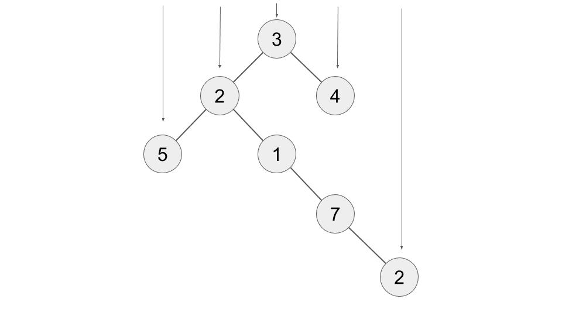

```python
def top_view(t):
    indexes = {}
    def helper(t, index, depth):
        ____________________________________________:
            ________________________________________
        ____________________________________________:
            ________________________________________
            ________________________________________:
                ____________________________________
        else:
            indexes[index] = _______________________
        ____________________________________________
        ____________________________________________
    helper(___________, ___________, ___________)
    sorted_indexes = sorted(indexes) # returns the sorted list of keys
    return [________________________________________]
```

### Solutions

#### Problem 1: tree_shuffle

This is a very conceptually hard problem. The hardest part (imo) is figuring out the three things to return in the `helper` function. Take a look at these slides (logic through an example starts at slide 2) [tree_shuffle diagram slides](https://docs.google.com/presentation/d/1BjzYuE3TH7LO7Fik5h9VYDALGEI3HxUBVGjP3zO2Hrw/edit?usp=sharing)

From looking at the slides, we notice that there are a couple things we need to keep track of. If we use the recursive leap of faith, we notice that a branch will either return a copy of the tree, or an updated tree that’s constructing the new shuffled tree. If none of the branches contain the goal node (so no shuffled tree) like the 4 node in the slides, then we’ll just return a copy of the tree.

However, if one of the branches has the goal node, then we can’t just return a copy of the tree. The current node we’re at can’t have the branch with the goal node. Furthermore, it needs to be a new branch. We need to figure out which tree to add our current node to as a new branch. So that’s another thing we have to keep track of.

So there’s three things we need to keep track of: 1. The root node of the shuffled tree (the label of this tree should be `val`) 2. The branch for our current node to go under (see slide 11-13) 3. Whether we found the goal node or not

These three things are what we’re returning from the helper function. So what we’ll do is we’ll setup some variables `new_parent`, `return_tree`, and `new_branches`. Then we’ll go through the branches and see if we hit the goal node. If the branch during that iteration doesn’t have the goal node, then we’ll just add that branch to `new_branches`. If the goal node is found, then `main_tree` should be the tree that we’ll return (the construction of the shuffled tree), `child_branch` will be the branch in the `main_tree` that we’ll have to put our current node under as a branch (i.e. #2 from above), and `is_new_parent` should be `True`. We don’t add this branch to `new_branches` because now the current node we’re at should a branch of `child_branch`. The rest of the code is for you to figure out :^)

```python
def tree_shuffle(t, val):
    def helper(t, val):
        t = copy_tree(t)
        if label.t == val:
            return t, t, True
        else:
            new_parent = None
            return_tree = None
            new_branches = []
            for b in t.branches:
                main_tree, child_branch, is_new_parent = helper(b, val)
                if is_new_parent:
                    new_parent = child_branch
                    return_tree = main_tree
                else:
                    new_branches += [b]
            updated_tree = Tree(t.label, new_branches)
            if new_parent:
                new_parent.branches += [updated_tree]
                return return_tree, updated_tree, True
            else:
                return updated_tree, updated_tree, False
    return helper(t, val)[0] # This takes the first value returned of the 3
```

#### Problem 2: top_view

View these slides to get a sense of the solutions: [top_view slides](https://docs.google.com/presentation/d/1xj-ggUK5dzsZNcXpcbb3DdVaBgdOpD6xGNSThu9msoI/edit?usp=sharing)

After that, we call the helper function with an initial index of $0$ (it could be any number) and depth of $0$ (technically can be any number but 0 makes the most sense). Since the helper function edits the indexes array, we want to output the array in the correct order. Since we subtracted 1 from the index when we went to the left and added 1 to the right, if we just sort the indexes and take the labels associated with that index, then we’ll have the correct output, which are the last two lines.

```python
def top_view(t):
    indexes = {}
    def helper(t, index, depth):
        if t is BTree.empty:
            return
        elif index in indexes.keys():
            index_depth = indexes[index][1]
            if depth < index_depth:
                indexes[index] = [t.label, depth]
        else:
            indexes[index] = [t.label, depth]
        helper(t.left, index - 1, depth + 1)
        helper(t.right, index + 1, depth + 1)
    helper(t, 0, 0)
    sorted_indexes = sorted(indexes) # returns the sorted list of keys
    return [indexes[idx][0] for idx in sorted_indexes]
```

## Linked Lists

### Problems

#### Problem 1.1: calculate

Implement the function `calculate` which takes in a function that accepts two arguments and a linked list `values` and returns the result of applying the binary function to each adjacent pair. This is kind of vague, it’s easier to explain with an example. Take the function `add` and the linked list `<7 3 6 4>`. Then it will compute $7+3+6+4$ which is $20$.

Assume `values` has at least one value in it.

```python
from operator import add, mul
def calculate(fn, values):
    '''
    >>> calculate(add, Link(3, Link(6, Link(-2))))
    7
    >>> calculate(mul, Link(3, Link(6, Link(-2, Link(0)))))
    0
    '''
    current = ________________________
    values = _________________________
    __________________________________:
        ______________________________
        ______________________________
    __________________________________
```

#### Problem 1.2: consolidate_link

Now implement the function `consolidate_link` which takes in a specifically designed linked list, `lnk`. `lnk` always has an even number of elements. The first element is always a binary function, the second element is a linked list of values. The third is a binary function (not necessarily different) and the fourth element is a linked list of values. And so on…

`consolidate_link` returns a new linked list that where it uses the functions and cosolidates the next elements numbers into one number using `calculate` written above.

```python
square_sub = lambda x, y: x**2 - y
def consolidate_link(lnk):
    '''
    >>> consolidate_link(Link(add, Link(1, Link(2))))
    Link(3)
    >>> consolidate_link(Link.empty)
    ()
    >>> values1 = Link(3, Link(6, Link(-2)))
    >>> values2 = Link(2, Link(0))
    >>> values3 = Link(1, Link(2, Link(3)))
    >>> s = Link(add, Link(values1, Link(mul, Link(values2, Link(square_sub, Link(values3))))))
    Link(12, Link(0, Link(-2)))
    '''
    __________________________________:
        ______________________________
    __________________________________:
        value = ______________________
        return _______________________
```

### Solutions

#### Problem 1.1: calculate

Here are some slides to get a sense of the problem: [calculate diagram slides](https://docs.google.com/presentation/d/1UM7mX7nZn4MiiAoB0hdpBj7HxDP6kkglQ2Jr1932rSw/edit?usp=sharing)

The key here is to set a variable to be updated over and over again, and that update will be the binary function, and the arguments will be the current variable and the next value in the linked list. The starting value for that variable, which I named `current` is the first value in the `values` linked list. Sine we don’t want to combine the first element twice, we need to set `values` to `values.rest`. Then we can iterate through and keep updating `current` and `values` until there are no more values to combine together.

```python
from operator import add, mul
def calculate(fn, values):
    '''
    >>> calculate(add, Link(3, Link(6, Link(-2))))
    7
    >>> calculate(mul, Link(3, Link(6, Link(-2, Link(0)))))
    0
    '''
    current = values.first
    values = values.rest
    while values is not Link.empty:
        current = fn(current, values.first)
        values = values.rest
    return current
```

#### Problem 1.2: consolidate_link

Here are some slides to get a sense of the problem: [consolidate_link diagram slides](https://docs.google.com/presentation/d/1wnfGKnY2Uyt28xNJtMBafQ9Oi5CjnAagH4yaY2rmsZ4/edit?usp=sharing)

We’ll use recursion to solve this problem. The slides go more in depth as to how to formulate the recursive cases. One thing to note is that `link.rest.rest` won’t error out because we always assume that there’s an even number of elements in the linked list `lnk` passed in. What isn’t gone over in the slides is the base case. If we hit an empty linked list, then we’ll just return an empty linked list to end our recursion. Here’s the solution coded up:

```python
square_sub = lambda x, y: x**2 - y
def consolidate_link(lnk):
    '''
    >>> consolidate_link(Link(add, Link(1, Link(2))))
    Link(3)
    >>> consolidate_link(Link.empty)
    ()
    >>> values1 = Link(3, Link(6, Link(-2)))
    >>> values2 = Link(2, Link(0))
    >>> values3 = Link(1, Link(2, Link(3)))
    >>> s = Link(add, Link(values1, Link(mul, Link(values2, Link(square_sub, Link(values3))))))
    Link(12, Link(0, Link(-2)))
    '''
    if lnk is Link.empty:
        return lnk
    else:
        value = calculate(lnk.first, lnk.rest.first)
        return Link(value, consolidate_link(link.rest.rest))
```

## Scheme

### Problems

#### Problem 1: compress

You’ve seen `uncompress` in discussion which takes a scheme list like this `'((a 3) (b 2) (a 2))` and turn it into this: `'(a a a b b a a)`. This is called run-length encoding. We’ll now do the opposite of this. So turn `'(a a a b b a a)` into `'((a 3) (b 2) (a 2))`.

```
(define (compress s)
    (define (helper lst val n)
        (cond
            ((__________________) ______________________________)
            ((__________________) ______________________________)
            (else (_____ (list _______) _______________________))
        )
    )
    (helper ________________________)
)
```

### Solutions

A helper function is defined for us to help keep track of how many of the same element we get in a row. The idea here is we’ll go through the list, and if the the element we’re at is the same as the previous values, we’ll increment `n` by $1$. If it’s not (i.e. we switch to another value in the list), then we’ll create a list that contains the value we’ve been checking, `val`, and `n`. Then we’ll repeat until we reach the end of our list, which is the null check in the beginning of the `cond`.

```
(define (compress s)
    (define (helper lst val n)
        (cond
            ((null? lst) nil)
            ((eq? (car lst) val) (helper (cdr lst) val (+ n 1)))
            (else (cons (list val n) (helper lst (car lst) 0)))
        )
    )
    (helper s (car s) 0)
)
```